# Introduction to Machine Learning in the Digital Humanities - Day 1

# tidy text in R

- The tidy text format has one-token-per-row.
- The tidytext library has function for getting text into a tidy format. For example, `unnest_tokens()`.

# `tidytext` Library

- `tidytext` is an example of an R library.
- A `library` is a set of functions that users and companies have written.
- Other libraries for handling text are: `spacyr`, `quanteda`, `cleanNLP`.

# Stop Words

Stop words are words that are not useful for an analysis, typically extremely common words such as “the”, “of”, “to”, and so forth in English.

The `tidytext` library has a dataset of stop words `stop_words`.

```r
stop_words
```

| word | lexicon |
| --- | --- |
| a | SMART |
| a's | SMART |
| able | SMART |
| about | SMART |
| above | SMART |
| according | SMART |
| accordingly | SMART |
| across | SMART |
| actually | SMART |
| after | SMART |

[output cut: 990 more lines]

For more information on these stop words look at the help menu or type `?stop_words`

# Stemming Words

The `SnowballC` library has a function that stems words.

```r
wordStem(c("win", "winning", "winner"))
```

```
[1] "win"    "win"    "winner"
```

More details on these algorithms can be found using help `?wordStem`

# Counting Words

If the text is in tidy text format and we want to count the number of words then we use the `count()` function in the `dplyr` library.

```r
vfquote <- c("Everything can be taken from a man but one thing: the last of the human freedoms—to choose one’s attitude in any given set of circumstances, to choose one’s own way.")
vf_df <- data_frame(vfquote)
unnest_tokens(vf_df,output = word,input = vfquote)
```

| word |
| --- |
| everything |
| can |
| be |
| taken |
| from |
| a |
| man |
| but |
| one |
| thing |

[output cut: 21 more lines]

```r
unnest_tokens(vf_df,output = word,input = vfquote) %>% count(word,sort = TRUE)
```

| word | n |
| --- | --- |
| choose | 2 |
| of | 2 |
| one’s | 2 |
| the | 2 |
| to | 2 |
| a | 1 |
| any | 1 |
| attitude | 1 |
| be | 1 |
| but | 1 |

[output cut: 16 more lines]

- This code takes the data in `unnest_tokens(vf_df,output = word,input = vfquote)` and *pipes* it into the `count()` function.
- Piping is only available if the `tidyverse` library is loaded.

# R or Python for Natural Language Processing?

- In this workshop we plan to use the RStudio to do interactive data analysis.
- RStudio is an example of an integrated development environment (IDE).
- Another similar IDE is Jupyter notebooks.
- Each has thier strengths and weaknesses.
- Both IDEs allow R and Python programs and libraries.
- I’ll stick to R for almost all of the examples.

# Statistics and Machine Learning

## Statistics

- Statistics is the study of variation.
- A certain town is served by two hospitals. In the larger hospital about 45 babies are born each day, and in the smaller hospital about 15 babies are born each day. As you know, about 50 percent of all babies are boys. However, the exact percentage varies from day to day. Sometimes it may be higher than 50 percent, sometimes lower. For a period of 1 year, each hospital recorded the days on which more than 60 percent of the babies born were boys. Which hospital do you think recorded more such days? (Tversky and Kahneman, 1974)

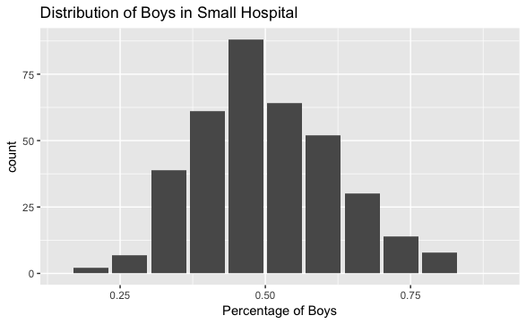

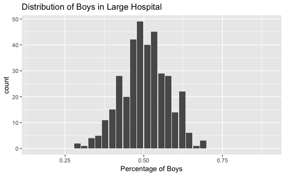

- The fundemental notion in statistics that a larger size sample size (number of boys in a hospital) reduces variability is usually not part of people’s intuitions.

## Machine Learning - Digit Recognition

- Machine learning (ML) is the science of getting computers to act without being explicitly programmed. ([Ng](https://www.coursera.org/learn/machine-learning)).
- ML involves data exploration, statistical pattern recogition, and statistical prediction.
- Consider the example of character recognition.
- The goal is classification of handwritten numerals. This problem captured the attention of the machine learning and neural network community for many years, and has remained a benchmark problem in the field. (Elements of Statis. Learning, pg. 404)
- Figure 11.9 shows some examples of normalized hand- written digits, automatically scanned from envelopes by the U.S. Postal Service. The original scanned digits are binary and of different sizes and orientations; the images shown here have been deslanted and size normalized, resulting in 16 × 16 grayscale images (Le Cun et al., 1990). These 256 pixel values are used as inputs to the neural network classifier. (Elements of Statis. Learning, pg. 404)

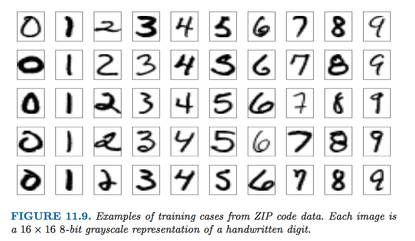

# Supervised versus Unsupervised Machine Learning

- This is an example of a **supervised** learning problem. We have a set of features (pixel intensity), and a response (the true identity of each image). The problem is to use the features to **predict** the response.
- If the response is quantitative then it is a regression problem.
- If the response is qualitative then it is a classification problem.
- Quantitative variables take on numerical values (e.g., height, weight, income), and qualitative variables take on values in one several classes (e.g., sex, authorship, brand of product purchased, sentiment, etc.).
- Classical statistical methods such as linear (quantitative response) or logistic (qualitative response with two categories) are often used.
- In **unsupervised** learning we observe only the features, but no response variable. This is a more challenging situation.

# Epicycle of Analysis

(Ref: Peng and Matsui, 2017)

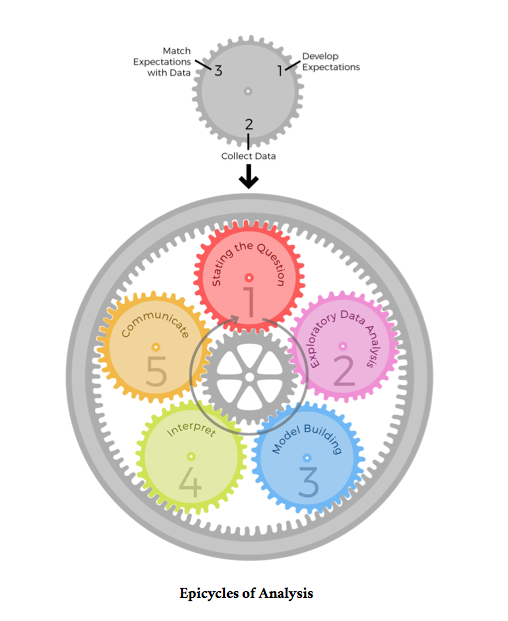

# Case study #1 - “Gotta Serve Somebody”

## tidy text and Data Vizualization

Some text from the Bob Dylan song, “Gotta Serve Somebody”

```r
bd_text <- c("You may be an ambassador to England or France
You may like to gamble, you might like to dance
You may be the heavyweight champion of the world
You may be a socialite with a long string of pearls
But you're gonna have to serve somebody, yes
Indeed you're gonna have to serve somebody
Well, it may be the devil or it may be the Lord
But you're gonna have to serve somebody
You might be a rock 'n' roll addict prancing on the stage
You might have drugs at your command, women in a cage
You may be a business man or some high-degree thief
They may call you doctor or they may call you chief
But you're gonna have to serve somebody, yes you are
You're gonna have to serve somebody
Well, it may be the devil or it may be the Lord
But you're gonna have to serve somebody
You may be a state trooper, you might be a young Turk
You may be the head of some big TV network
You may be rich or poor, you may be blind or lame
You may be living in another country under another name
But you're gonna have to serve somebody, yes you are
You're gonna have to serve somebody
Well, it may be the devil or it may be the Lord
But you're gonna have to serve somebody
You may be a construction worker working on a home
You may be living in a mansion or you might live in a dome
You might own guns and you might even own tanks
You might be somebody's landlord, you might even own banks
But you're gonna have to serve somebody, yes
You're gonna have to serve somebody
Well, it may be the devil or it may be the Lord
But you're gonna have to serve somebody
You may be a preacher with your spiritual pride
You may be a city councilman taking bribes on the side
You may be workin' in a barbershop, you may know how to cut hair
You may be somebody's mistress, may be somebody's heir
But you're gonna have to serve somebody, yes
You're gonna have to serve somebody
Well, it may be the devil or it may be the Lord
But you're gonna have to serve somebody
Might like to wear cotton, might like to wear silk
Might like to drink whiskey, might like to drink milk
You might like to eat caviar, you might like to eat bread
You may be sleeping on the floor, sleeping in a king-sized bed
But you're gonna have to serve somebody, yes
Indeed you're gonna have to serve somebody
Well, it may be the devil or it may be the Lord
But you're gonna have to serve somebody
You may call me Terry, you may call me Timmy
You may call me Bobby, you may call me Zimmy
You may call me R.J., you may call me Ray
You may call me anything but no matter what you say
Still, you're gonna have to serve somebody, yes
You're gonna have to serve somebody
Well, it may be the devil or it may be the Lord
But you're gonna have to serve somebody")
bd_text
```

```
[1] "You may be an ambassador to England or France\nYou may like to gamble, you might like to dance\nYou may be the heavyweight champion of the world\nYou may be a socialite with a long string of pearls\nBut you're gonna have to serve somebody, yes\nIndeed you're gonna have to serve somebody\nWell, …
```

Now let’s turn it into a tidy text dataset. First put the text into a data frame

```r
bd_text_df <- data_frame(line = 1, text = bd_text)
bd_text_df
```

| line | text |
| --- | --- |
| 1 | You may be an ambassador to England or France\nYou may like to gamble, you might like to dance\nYou may be the heavyweight champion of the world\nYou may be a socialite with a long string of pearls\nB… |

A *token* is a meaningful unit of text, such as a word, that we are intrested in using for analysis. Tokenization is the process of splitting text into tokens.

A text is ready for analysis if it has one-token-per-row. A token is often a single word but it could also be a sentence or a paragraph.

The tidytext paackage provides functionality to convert to a one-term-per-row format.

We can use `unnest_tokens()` to break the the text into tokens.

```r
bd_text_df %>% unnest_tokens(word, text)
```

| line | word |
| --- | --- |
| 1 | you |
| 1 | may |
| 1 | be |
| 1 | an |
| 1 | ambassador |
| 1 | to |
| 1 | england |
| 1 | or |
| 1 | france |
| 1 | you |

[output cut: 528 more lines]

We can use the `count()` function in the `dplyr` library to find the most common words in the text.

```r
bd_text_df %>% unnest_tokens(word,text) %>% count(word,sort = TRUE)
```

| word | n |
| --- | --- |
| may | 42 |
| you | 41 |
| be | 34 |
| to | 31 |
| have | 22 |
| gonna | 21 |
| serve | 21 |
| somebody | 21 |
| you're | 21 |
| the | 20 |

[output cut: 126 more lines]

We can create a plot of these frequencies using the ggplot2 library.

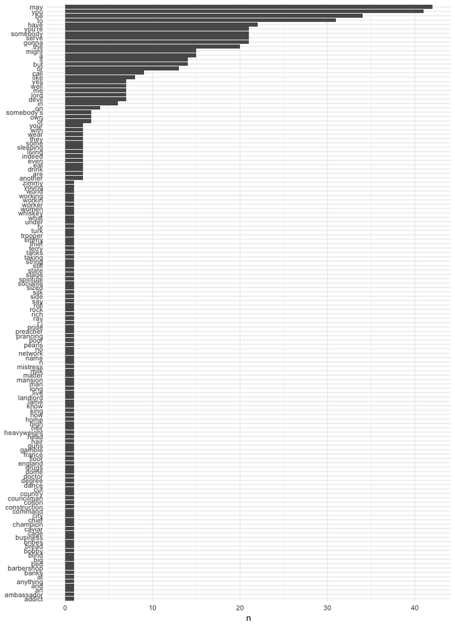

```r
bd_text_df %>% unnest_tokens(word,text) %>% count(word,sort = TRUE) %>%
mutate(word = reorder(word,n)) %>%
  ggplot(aes(word,n),size = 7) +
  geom_col() +
  xlab(NULL) +
  theme_minimal() +
  coord_flip()
```

## Questions

1. Create a bar chart of the word frequencies.
2. Are there any stop words that you think should be removed?
3. Should the words be stemmed?

# Case study #2 - H.G. Wells and Brontë sisters

## Data Wrangling and Statistical Analysis

H. G. Wells books: The Time Machine, The War of the Worlds, The Invisible Man, and The Island of Doctor Moreau.

```r
# Download HG Wells books from Gutenberg
hgwells <- gutenberg_download(c(35, 36, 5230, 159))
tidy_hgwells <- hgwells %>%
  # the text of the four HG Wells books are separated into word tokens
  unnest_tokens(word, text) %>%
  # anti_join with stop_words removes stop words
  anti_join(stop_words)
```

Are any words not lowercase characters that may be in single quaotes?

The function `str_detect()` can detect the presence or absence of a pattern in a string.

The pattern `[a-z']+` is an example of a **regular expression**. Regular expressions are a tool for describing patterns in strings.

The regular expression `[a-z']+` matches every character between a and z with or without single quotations.

```r
sum(str_detect(tidy_hgwells$word, "[a-z']+") == FALSE)
```

```
[1] 31
```

What are the most common words in these novels?

```r
tidy_hgwells <- tidy_hgwells %>% mutate(word = str_extract(word, "[a-z']+")) %>%
  count(word,sort = T)
tidy_hgwells
```

| word | n |
| --- | --- |
| time | 454 |
| people | 302 |
| door | 260 |
| heard | 249 |
| black | 232 |
| stood | 229 |
| white | 222 |
| hand | 218 |
| kemp | 213 |
| eyes | 210 |

[output cut: 990 more lines]

Now get works of Brontë sisters.

```r
bronte <- gutenberg_download(c(1260, 768, 969, 9182, 767))
tidy_bronte <- bronte %>%
  unnest_tokens(word, text) %>%
  anti_join(stop_words)
```

What are the most common words in these novels of the Brontë sisters?

```r
tidy_bronte <- tidy_bronte  %>% mutate(word = str_extract(word, "[a-z']+")) %>%
  count(word,sort = T)
```

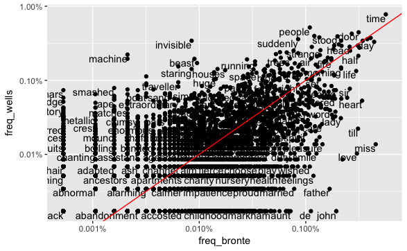

```r
comparison <- tidy_bronte %>% inner_join(tidy_hgwells,by="word")  %>% mutate(freq_bronte=n.x/sum(n.x),freq_wells=n.y/sum(n.y))
ggplot(comparison, aes(freq_bronte,freq_wells)) + geom_point() +
  geom_text(aes(label = word), check_overlap = TRUE, vjust = 1, hjust = 1) +
  scale_x_log10(labels = percent_format()) +
  scale_y_log10(labels = percent_format()) +
  geom_abline(color = "red")
```

What have we plotted? How can we interpret this plot? Is it meaningful?

All the words that appear in both texts. But, among all words in the text how many appear in one text and not the other?

```r
comparison_all <-
  tidy_bronte %>% full_join(tidy_hgwells, by = "word") %>%
  mutate(br_in = if_else(is.na(n.x), 0, 1),
  well_in = if_else(is.na(n.y), 0, 1))
  with(comparison_all, CrossTable(br_in, well_in, prop.chisq = F))
```

[output not shown]

- If a word is randomly selected in one of the Well’s novels then there is a 0.71 chance that it will also appear in the Brontë sisters works. This is also called the conditional probability that the word appears in Brontë sisters *given that* it appears in Wells.
- If a word is randomly selected in one of the Brontë sisters works then there is a 0.37 chance that it will also appear in the Well’s novels. This is also called the conditional probability that the word appears in Wells *given that* it appears in Brontë sisters.

Did Wells influence the Brontë sisters?

# Case study # 3

- Class chooses a text to work on.
- Class members present their work.